PHY-2100 — Sciences de l'Espace

# Devoir 3

### Équipe de recherche

**Alex Baker** — 537 050 929  
**Justine Jean** — 537 287 332  
**Léanne Dupuis** — 537 142 110  
**Zak Roy** — 537 289 880

### Informations académiques

**Cours :** PHY-2100 – Sciences de l'espace (H26)  
**Remise :** 30 mars 2026  
**Encadrement :** Pr. Richard L. Lachance

## Guide de lecture et d'exécution du notebook

Ce notebook est structuré pour répondre point par point à l'énoncé du devoir 3.

### Ordre recommandé d'exécution

1. Exécuter toutes les cellules dans l'ordre, du haut vers le bas (`Run All`).
2. Vérifier que les cellules de calculs principaux et de figures s'exécutent sans erreur.
3. Vérifier les résultats de synthèse dans le tableau final (section 2.10).

### Logique scientifique suivie

- Définition du scénario et des paramètres du projectile (section 1).
- Vérification dimensionnelle des modèles physiques (section 2.0).
- Implémentation des modèles : $\rho(z)$, $g(z)$, traînée quadratique, et (bonus) $C_D(M)$ (sections 2.1 à 2.2).
- Intégration numérique avec trois solveurs (Euler, RK4, RK45) et comparaison à la solution analytique sans traînée (section 2.3).
- Extraction automatique des grandeurs d'intérêt : angle optimal, portée, apogée, temps de vol, charges g (section 2.4).
- Analyse des résultats via figures et validation expérimentale HARP (sections 2.5 à 3).

### Comment interpréter les sorties

- Les valeurs affichées dans les sections de résultats sont générées automatiquement à l'exécution.
- Les chiffres de la discussion et de la conclusion doivent être interprétés comme des ordres de grandeur cohérents avec ces sorties.
- Les légères variations numériques (ex.: angle optimal 50–51°) proviennent du pas angulaire, des tolérances numériques et de l'arrondi d'affichage.

## Explication détaillée des sections de code et des figures

Cette section résume précisément le rôle de chaque bloc de code majeur et la lecture attendue des graphiques, pour faciliter l’évaluation du rapport.

### Bloc d'initialisation (importations + style)

- Initialise les bibliothèques scientifiques (`numpy`, `scipy`, `matplotlib`).
- Configure un style graphique uniforme pour toutes les figures (couleurs, polices, grilles, légendes).
- Définit `OUTPUT_DIR` pour enregistrer automatiquement les figures produites.

### Bloc constantes et paramètres

- Déclare les constantes physiques ($R_\oplus$, $g_{eq}$, $\rho_0$, $h_0$).
- Déclare les paramètres projectile (masse, diamètre, aire frontale).
- Construit la base de comparaison expérimentale HARP (`EXP`) et le cas de référence Round 28.

### Bloc modèles physiques

- `gravity(z)` : gravité décroissante avec l’altitude.
- `air_rho(z)` : densité de l’air exponentielle.
- `sound_speed(z)` et `cd_mach(v,z)` : outils bonus pour une loi de traînée dépendante du Mach.

### Bloc équations du mouvement

- `eom(...)` implémente les EDO du système $[x, y, v_x, v_y]$.
- `_ground_event(...)` arrête l’intégration quand le projectile revient au sol.

### Bloc solveurs numériques

- `run_euler` : solveur explicite d’ordre 1 (référence pédagogique).
- `run_rk4` : solveur explicite d’ordre 4 (compromis précision/coût).
- `run_ode45` : solveur adaptatif RK45 (`solve_ivp`), utilisé comme référence numérique.
- `run_analytic` : solution sans frottement (cas théorique idéal de comparaison).

### Bloc d'analyse post-traitement

- `get_key_points` extrait automatiquement apogée, portée et temps clés.
- `compute_gload` calcule la charge structurale en unités de $g_0$.
- `scan_angles` construit les courbes de performance en fonction de l’angle de lancement.

### Lecture des figures

- **Figure 1** : comparaison des trajectoires, balayage d’angles, portée max et apogée en fonction de $\theta_0$.
- **Figure 2** : évolution temporelle de la position et des composantes de vitesse.
- **Figure 3 (bonus)** : validation expérimentale, courbe $y(v)$, charge g, et comparaison $C_D(M)$.
- **Figure d’affinage** : raffinement local autour de $\theta_{opt}$ pour augmenter la robustesse de l’estimation.

### Tableau final

- Regroupe toutes les grandeurs clés extraites automatiquement.
- Sert de référence unique pour les chiffres reportés dans la discussion et la conclusion.

```python
import numpy as np
import matplotlib.pyplot as plt
import matplotlib.gridspec as gridspec
from matplotlib.lines import Line2D
from scipy.integrate import solve_ivp
from pathlib import Path
from IPython import get_ipython
import warnings
warnings.filterwarnings('ignore')

# Mode notebook uniquement: affichage inline fiable dans VS Code/Jupyter
ip = get_ipython()
if ip is not None:
    ip.run_line_magic('matplotlib', 'inline')

OUTPUT_DIR = Path.cwd()

# ══════════════════════════════════════════════════════════════════════
#  00.  THÈME GRAPHIQUE  (espace sombre)
# ══════════════════════════════════════════════════════════════════════
BG, PANEL, BORDER = '#0D1117', '#161B22', '#30363D'
TEXT, MUTED = '#F0F6FC', '#8B949E'
C = dict(
    nodrag='#58A6FF',   # bleu  – trajectoire analytique (sans drag)
    euler ='#FF7B72',   # coral – Euler
    rk4   ='#FFD700',   # or    – RK4
    ode45 ='#56D364',   # vert  – solve_ivp / ode45
    exp   ='#FF4444',   # rouge – données expérimentales
    gload ='#BC8CFF',   # viola – charge g
    hi    ='#FFA657',   # orange
)

plt.rcParams.update({
    'figure.facecolor': BG,   'axes.facecolor':  PANEL,
    'axes.edgecolor':   BORDER,'axes.labelcolor': TEXT,
    'axes.titlecolor':  TEXT,  'xtick.color':     MUTED,
    'ytick.color':      MUTED, 'grid.color':      BORDER,
    'grid.linestyle':   '--',  'grid.alpha':      0.5,
    'text.color':       TEXT,  'legend.facecolor': PANEL,
    'legend.edgecolor': BORDER,'font.family':     'DejaVu Sans',
    'font.size':        10,    'axes.titlesize':   12,
    'axes.labelsize':   10,    'lines.linewidth':  2.0,
    'figure.dpi':       130,   'axes.titlepad':    10,
})


def style_ax(ax, title='', xl='', yl=''):
    """Applique le style sombre uniformément à un axe."""
    for sp in ax.spines.values():
        sp.set_edgecolor(BORDER)
    ax.tick_params(colors=MUTED, length=4)
    ax.grid(True, alpha=0.4)
    if title: ax.set_title(title, fontweight='bold', pad=8)
    if xl:    ax.set_xlabel(xl)
    if yl:    ax.set_ylabel(yl)
```

## 1. Choix du projectile analysé

Pour ce devoir, on analyse un projectile HARP, plus précisément le Martlet 2C. Ce choix est pertinent parce qu’il s’agit d’un projectile réel, bien documenté, et particulièrement intéressant du point de vue balistique puisque ses vitesses de lancement sont hypersoniques. Cela permet d’étudier clairement l’effet de la traînée atmosphérique sur la portée, l’apogée et l’angle optimal de lancement.

Le scénario retenu est basé sur les essais HARP de Yuma Proving Ground. Le cas principal de référence est le Round 28 (vitesse initiale maximale), utile pour comparer des simulations numériques à des données expérimentales réelles.

## Spécifications techniques du projectile

Les paramètres utilisés dans le modèle sont les suivants :

- projectile : HARP Martlet 2C
- masse : 83.9 kg
- diamètre : 12.7 cm
- aire frontale : 126.68 cm²
- coefficient de traînée constant calibré : $C_D \approx 0.2423$
- vitesse initiale typique du Round 28 : $v_0 \approx 2163$–$2164\,\mathrm{m/s}$
- nombre de Mach initial : environ 6.4

La cellule suivante définit explicitement toutes les constantes physiques et les paramètres utilisés dans la simulation.

```python
# ══════════════════════════════════════════════════════════════════════
#  1.  CONSTANTES & PARAMÈTRES HARP
# ══════════════════════════════════════════════════════════════════════
R_EARTH  = 6_371_000.0   # m
G_EQ     = 9.78          # m/s²  (valeur imposée par le devoir)
H0       = 8_500.0       # m     (hauteur d'échelle, devoir)
RHO_0    = 1.225         # kg/m³ (ISA, z = 0)
G0_SI    = 9.80665       # m/s²  (standard BIPM, pour la charge g)

# ── Martlet 2C  (Murphy & Bull 1967) ─────────────────────────────────
M_PROJ  = 83.9                       # kg   masse en vol (sans sabot)
D_PROJ  = 0.127                      # m    corps 5 pouces
A_PROJ  = np.pi * (D_PROJ / 2)**2   # m²   section frontale ≈ 0.01267 m²

# Calibration C_D depuis Figure 6 de Murphy & Bull
#   W / (C_D · A) = 5600 lb/ft²  →  C_D = m / (A · WCDA)
_WCDA   = 5600 * 0.453592 / (0.3048**2)   # 5600 lb/ft² → kg/m²
CD_CONST = M_PROJ / (A_PROJ * _WCDA)       # ≈ 0.2423

# Vitesse terminale (chute verticale, z = 0, calcul de sanité)
V_TERM  = np.sqrt(M_PROJ * G0_SI / (0.5 * RHO_0 * CD_CONST * A_PROJ))

# ── Conversions ───────────────────────────────────────────────────────
ft2ms  = lambda v: v * 0.3048    # ft/s → m/s
kft2m  = lambda d: d * 304.8    # kft  → m

# ── Données expérimentales — Table II, Murphy & Bull 1967 ─────────────
# Colonnes : [θ [°], v₀ [m/s], apogée [m], portée [m]]
EXP = np.array([
    [83.9, ft2ms(5930), kft2m(415), kft2m(158)],
    [84.0, ft2ms(5630), kft2m(375), kft2m(144)],
    [85.0, ft2ms(6800), kft2m(540), kft2m(167)],
    [84.5, ft2ms(6780), kft2m(535), kft2m(167)],
    [84.3, ft2ms(6650), kft2m(510), kft2m(182)],
    [83.6, ft2ms(6400), kft2m(490), kft2m(196)],
    [83.8, ft2ms(6650), kft2m(530), kft2m(207)],
    [83.7, ft2ms(5850), kft2m(400), kft2m(162)],
    [84.8, ft2ms(7100), kft2m(590), kft2m(188)],   # Round 28  ← RECORD
    [83.5, ft2ms(6350), kft2m(480), kft2m(198)],
    [83.6, ft2ms(5720), kft2m(367), kft2m(149)],
    [84.2, ft2ms(6750), kft2m(550), kft2m(195)],
])

# Round 28 — cas de référence (vitesse maximale, apogée record ~180 km)
V0_R28   = ft2ms(7100)    # ≈ 2162.7 m/s
TH_R28   = 84.8           # °
APO_R28  = kft2m(590)     # ≈ 179 832 m  ≈ 180 km
RNG_R28  = kft2m(188)     # ≈  57 302 m  ≈  57 km
```

## 2.0 Analyse dimensionnelle

L'énoncé stipule : *« l'analyse dimensionnelle est toujours de mise »*.

### Traînée quadratique de Newton

$$F_D = \tfrac{1}{2}\,\rho(z)\,C_D\,A\,v^2$$

$$[F_D] = \mathrm{kg\,m^{-3}} \cdot 1 \cdot \mathrm{m^2} \cdot \mathrm{m^2\,s^{-2}} = \mathrm{kg\cdot m\cdot s^{-2}} = \mathbf{N} \quad \checkmark$$

### Accélération de traînée

$$a_D = F_D/m \quad\Rightarrow\quad [a_D] = \mathrm{N/kg} = \mathbf{m\,s^{-2}} \quad \checkmark$$

### Paramètre $\mu_N$

$$\mu_N = \frac{\rho_0\,C_D\,A}{2m} \quad\Rightarrow\quad [\mu_N] = \frac{\mathrm{kg\,m^{-3}\cdot m^2}}{\mathrm{kg}} = \mathbf{m^{-1}} \quad \checkmark$$

### Gravité variable

$$g(z)=g_\mathrm{eq}\!\left(\frac{R_\oplus}{R_\oplus+z}\right)^{\!2} \quad\Rightarrow\quad [g] = \mathrm{m\,s^{-2}}\cdot 1 = \mathbf{m\,s^{-2}} \quad \checkmark$$

```python
# ANALYSE DIMENSIONNELLE — vérification numérique
import numpy as np  # déjà importé, redondant mais rend la cellule autonome
import warnings; warnings.filterwarnings('ignore')

_rho0, _CD = 1.225, 0.2422
_A   = np.pi*(0.127/2)**2
_m   = 83.9
_v0  = 2164.0
_geq = 9.78
_RE  = 6_371_000.0
_h0  = 8_500.0
_z   = 50_000.0

FD   = 0.5 * _rho0 * _CD * _A * _v0**2
aD   = FD / _m
muN  = 0.5 * _rho0 * _CD * _A / _m
g_z  = _geq * (_RE / (_RE + _z))**2
rho_z = _rho0 * np.exp(-_z/_h0)

print("─"*52)
print("  Verification numerique — analyse dimensionnelle")
print("─"*52)
print(f"  F_D(z=0) = {FD:>10,.0f} N  [kg.m/s2  OK]")
print(f"  a_D(z=0) = {aD:>10.2f} m/s2  [{aD/9.81:.1f} x g0  OK]")
print(f"  mu_N(z=0)= {muN:>10.4e} m-1  [m-1  OK]")
print(f"  g(50 km) = {g_z:>10.4f} m/s2  (red. {(g_z-_geq)/_geq*100:.2f}%  OK)")
print(f"  rho(50km)= {rho_z:>10.4e} kg/m3  [{rho_z/_rho0:.4f} x rho0  OK]")
print("─"*52)
```

```
────────────────────────────────────────────────────
  Verification numerique — analyse dimensionnelle
────────────────────────────────────────────────────
  F_D(z=0) =      8,800 N  [kg.m/s2  OK]
  a_D(z=0) =     104.89 m/s2  [10.7 x g0  OK]
  mu_N(z=0)= 2.2398e-05 m-1  [m-1  OK]
  g(50 km) =     9.6283 m/s2  (red. -1.55%  OK)
  rho(50km)= 3.4156e-03 kg/m3  [0.0028 x rho0  OK]
────────────────────────────────────────────────────
```

## 2.1 Modèle de densité de l’air, gravité variable et traînée

La densité est modélisée par : $$ \rho(y)=\rho_0 e^{-y/h_0}, $$ ce qui signifie que l’air devient rapidement moins dense avec l’altitude. La gravité est modélisée par : $$ g(y)=g_{\mathrm{eq}}\left(\frac{R_\oplus}{R_\oplus+y}\right)^2, $$ ce qui permet de tenir compte du fait que le projectile atteint des altitudes très grandes. La traînée est prise sous forme quadratique : $$ F_D = \frac12 \rho(y) C_D A v^2. $$

Dans le cas principal, j’utilise un coefficient de traînée constant. En bonus, le code contient aussi une loi $C_D(M)$ dépendant du Mach.

```python
# ══════════════════════════════════════════════════════════════════════
#  2.1  MODÈLES PHYSIQUES
# ══════════════════════════════════════════════════════════════════════

def gravity(z):
    """g(z) = g_eq · (R⊕ / (R⊕ + z))²  [m/s²]"""
    return G_EQ * (R_EARTH / (R_EARTH + max(float(z), 0.0)))**2


def air_rho(z):
    """ρ(z) = ρ₀ · exp(−z / h₀)  [kg/m³]"""
    return RHO_0 * np.exp(-max(float(z), 0.0) / H0)


def sound_speed(z):
    """Vitesse du son — atmosphère standard ISA  [m/s]"""
    z = max(float(z), 0.0)
    T = 288.15 - 6.5e-3 * z if z < 11_000 else max(216.65 + 1e-3 * (z - 20_000), 180.0)
    return np.sqrt(1.4 * 287.05 * T)


def cd_mach(v, z):
    """
    C_D(M) — formule des notes de cours (slide II-35)
    Valable pour systèmes sans portance significative.
    M ≤ 0.85  :  C_D ≈ 0.20  (subsonique, incompressible)
    M  > 0.85  :  C_D ≈ 0.11 + 0.82/M² − 0.55/M⁴
    """
    M = v / sound_speed(z)
    if M <= 0.85:
        return 0.20
    return max(0.11 + 0.82 / M**2 - 0.55 / M**4, 0.08)
```

## 2.2 Équations du mouvement

Le mouvement est décrit à l’aide de l’état : $$ \mathbf{s}=[x,\ y,\ v_x,\ v_y]. $$

Les équations différentielles sont : $$ \dot{x}=v_x,\qquad \dot{y}=v_y, $$ $$ \dot{v}_x=-\frac{1}{2m}\rho(y)C_DA\,v\,v_x, $$ $$ \dot{v}_y=-g(y)-\frac{1}{2m}\rho(y)C_DA\,v\,v_y, $$ avec $$ v=\sqrt{v_x^2+v_y^2}. $$

Les conditions initiales sont : $$ x(0)=0,\quad y(0)=0,\quad v_x(0)=v_0\cos\theta_0,\quad v_y(0)=v_0\sin\theta_0. $$

La cellule suivante contient la fonction des équations du mouvement et l’événement qui arrête l’intégration lorsque le projectile revient au sol.

### 2.2a Dérivation algébrique des équations de mouvement

**Principe :** $\sum\vec{F} = m\vec{a}$ (Newton, 2D)

**Forces :**

| Force | Direction | Expression |
| --- | --- | --- |
| Gravité | $-\hat{y}$ | $-mg(z)\,\hat{y}$ |
| Traînée | $-\hat{v}$ | $-\frac{1}{2}\rho C_D A v^2\,\hat{v}$ |

**Composante $x$ :**

$$\boxed{\ddot{x} = -\mu_N(z)\,v\,v_x} \qquad\text{avec}\quad\mu_N(z)=\frac{\rho(z)C_D A}{2m}$$

**Composante $y$ :**

$$\boxed{\ddot{y} = -g(z) - \mu_N(z)\,v\,v_y}$$

**Forme vectorielle état** $\mathbf{s}=[x,y,v_x,v_y]$ **:**

$$\frac{d\mathbf{s}}{dt}=\begin{pmatrix}v_x\\v_y\\-\mu_N v\,v_x\\-g-\mu_N v\,v_y\end{pmatrix}$$

**Solution analytique** ($\mu_N=0$, $g$ constant) : $$x(t)=v_{0x}t, \quad y(t)=v_{0y}t-\tfrac{1}{2}gt^2$$ $$t_\mathrm{apo}=v_{0y}/g, \quad t_\mathrm{vol}=2v_{0y}/g$$

```python
# ══════════════════════════════════════════════════════════════════════
#  2.2  ÉQUATIONS DU MOUVEMENT
# ══════════════════════════════════════════════════════════════════════

def eom(t, s, drag=True, cd_mode='const'):
    """
    Fonction dérivée  ds/dt = f(t, s)   avec  s = [x, y, vx, vy]

    Sans frottement :
        ẍ = 0
        ÿ = −g(y)

    Avec traînée quadratique de Newton :
        ẍ = −μ_N vₓ |v|
        ÿ = −g(y) − μ_N v_y |v|    où  μ_N = ρ(y) C_D A / (2m)
    """
    x, y, vx, vy = s
    y  = max(float(y), 0.0)
    g  = gravity(y)
    ax, ay = 0.0, -g

    if drag:
        v = np.hypot(vx, vy)
        if v > 1e-10:
            r  = air_rho(y)
            cd = CD_CONST if cd_mode == 'const' else cd_mach(v, y)
            aD = 0.5 * r * cd * A_PROJ * v**2 / M_PROJ   # |a_drag|
            ax -= aD * vx / v
            ay -= aD * vy / v

    return [vx, vy, ax, ay]


def _ground_event(t, s, *a):
    """Condition d'arrêt : y = 0  (atterrissage)"""
    return s[1]

_ground_event.terminal  = True
_ground_event.direction = -1
```

## 2.3 Méthodes numériques utilisées

On utilise les méthodes numériques suivantes, pour pouvoir les comparés :

- Euler explicite
- Runge–Kutta d’ordre 4 (RK4)
- RK45 adaptatif avec `solve_ivp`, l’équivalent Python de `ode45`

```python
# ══════════════════════════════════════════════════════════════════════
#  2.3  INTÉGRATEURS NUMÉRIQUES
# ══════════════════════════════════════════════════════════════════════
def _ic(theta_deg, v0):
    """Conditions initiales  s₀ = [0, 0, v₀ cos θ, v₀ sin θ]"""
    th = np.radians(theta_deg)
    return np.array([0., 0., v0 * np.cos(th), v0 * np.sin(th)])


def run_euler(theta_deg, v0, dt=0.25, drag=True, cd_mode='const'):
    """
    Méthode d'Euler explicite  (1er ordre — O(Δt))
    s_{n+1} = s_n + Δt · f(t_n, s_n)
    Arrêt dès que y passe sous zéro (interpolation linéaire pour l'atterrissage exact).
    """
    s = _ic(theta_deg, v0)
    ts, traj = [0.], [s.copy()]
    t = 0.
    while t < 4000:
        d     = np.array(eom(t, s, drag, cd_mode))
        s_new = s + dt * d
        if s_new[1] < 0 and s[1] >= 0:
            # Interpolation linéaire → instant exact d'atterrissage
            frac    = s[1] / (s[1] - s_new[1])
            s_land  = s + frac * dt * d
            s_land[1] = 0.0
            ts.append(t + frac * dt)
            traj.append(s_land)
            break
        s = s_new
        t += dt
        ts.append(t)
        traj.append(s.copy())
    return np.array(ts), np.array(traj)


def run_rk4(theta_deg, v0, dt=1.0, drag=True, cd_mode='const'):
    """
    Runge-Kutta d'ordre 4  (4e ordre — O(Δt⁴))
    s_{n+1} = s_n + (Δt/6)(k₁ + 2k₂ + 2k₃ + k₄)
    Arrêt dès que y < 0 avec interpolation linéaire pour l'atterrissage.
    """
    s = _ic(theta_deg, v0)
    ts, traj = [0.], [s.copy()]
    t = 0.
    while t < 4000:
        k1 = np.array(eom(t,        s,           drag, cd_mode))
        k2 = np.array(eom(t+dt/2,   s+dt/2*k1,  drag, cd_mode))
        k3 = np.array(eom(t+dt/2,   s+dt/2*k2,  drag, cd_mode))
        k4 = np.array(eom(t+dt,     s+dt*k3,    drag, cd_mode))
        s_new = s + dt/6 * (k1 + 2*k2 + 2*k3 + k4)
        if s_new[1] < 0 and s[1] >= 0:
            frac   = s[1] / (s[1] - s_new[1])
            d_avg  = (k1 + 2*k2 + 2*k3 + k4) / 6
            s_land = s + frac * dt * d_avg
            s_land[1] = 0.0
            ts.append(t + frac * dt)
            traj.append(s_land)
            break
        s = s_new
        t += dt
        ts.append(t)
        traj.append(s.copy())
    return np.array(ts), np.array(traj)


def run_ode45(theta_deg, v0, drag=True, cd_mode='const', tol=1e-7):
    """
    scipy solve_ivp  méthode RK45  (4e-5e ordre adaptatif)
    Équivalent direct du solveur ode45 de MATLAB.
    Le pas de temps est ajusté automatiquement pour maintenir
    l'erreur locale en-dessous de la tolérance spécifiée.
    """
    y0  = _ic(theta_deg, v0)
    sol = solve_ivp(
        fun=lambda t, y: eom(t, y, drag, cd_mode),
        t_span=[0, 4000],
        y0=y0,
        method='RK45',
        events=_ground_event,
        rtol=tol, atol=tol,
        max_step=2.0,
    )
    s = sol.y.T.copy()
    s[:, 1] = np.maximum(s[:, 1], 0.)
    return sol.t, s


def run_analytic(theta_deg, v0, N=4000):
    """
    Solution analytique — trajectoire parabolique
    (g constant = G_EQ, sans frottement)
    x(t) = v₀ₓ t
    y(t) = v₀_y t − ½ g t²
    """
    th       = np.radians(theta_deg)
    v0x, v0y = v0 * np.cos(th), v0 * np.sin(th)
    t_land   = 2 * v0y / G_EQ
    t        = np.linspace(0, t_land, N)
    x        = v0x * t
    y        = np.maximum(v0y * t - 0.5 * G_EQ * t**2, 0.)
    vx       = np.full_like(t, v0x)
    vy       = v0y - G_EQ * t
    return t, np.column_stack([x, y, vx, vy])
```

## 2.4 Fonctions d'analyse

Pour exploiter les trajectoires calculées, on utilise des fonctions qui servent à extraire automatiquement :

- l’apogée
- la portée
- le temps de vol
- la position de l’apogée
- la charge structurale en $g$
- le balayage angulaire permettant de trouver $\theta_{\mathrm{opt}}$

Cette partie du code centralise donc toute l’analyse des résultats.

```python
# ══════════════════════════════════════════════════════════════════════
#  2.4  FONCTIONS D'ANALYSE
# ══════════════════════════════════════════════════════════════════════

def get_key_points(ts, ss):
    """
    Retourne les instants et positions clés :
        (t_apo, x_apo, y_apo, t_land, x_range)
    """
    ia = np.argmax(ss[:, 1])
    return ts[ia], ss[ia, 0], ss[ia, 1], ts[-1], ss[-1, 0]


def compute_gload(ts, ss, cd_mode='const'):
    """
    Charge g structurale sur le projectile  [g₀]
    En vol balistique, le projectile est en chute libre → il ne "ressent"
    pas la gravité. La seule force structurale est la traînée aérodynamique :
        n_g = |a_drag| / g₀ = ρ(y) C_D A v² / (2 m g₀)
    """
    loads = np.zeros(len(ts))
    for i, s in enumerate(ss):
        v = np.hypot(s[2], s[3])
        if v > 1e-9:
            r  = air_rho(s[1])
            cd = CD_CONST if cd_mode == 'const' else cd_mach(v, s[1])
            loads[i] = 0.5 * r * cd * A_PROJ * v**2 / (M_PROJ * G0_SI)
    return loads


def scan_angles(v0, angles, drag=True, cd_mode='const'):
    """Balayage des angles via ode45 → tableau [theta, x_apo, y_apo, x_range]"""
    out = []
    for th in angles:
        t, s = run_ode45(th, v0, drag=drag, cd_mode=cd_mode)
        if not drag:
            t, s = run_analytic(th, v0)
        _, xa, ya, _, xr = get_key_points(t, s)
        out.append([th, xa, ya, xr])
    return np.array(out)
```

## 2.5 Recherche de l’angle optimal

Pour déterminer l’angle donnant la portée maximale, on effectue un balayage numérique d’une série d’angles. Pour chaque angle, le code calcule la trajectoire complète, puis extrait automatiquement la portée finale et l’apogée.

Le résultat principal obtenu avec traînée est un angle optimal voisin de $50$–$51^\circ$ (selon le pas angulaire et l’arrondi).

Dans le cas sans frottement, le balayage discret donne une valeur proche de $45^\circ$, ce qui est cohérent avec la théorie balistique idéale. Les petits écarts observés viennent de la discrétisation angulaire et des tolérances numériques, et non d’un effet physique.

```python
# ══════════════════════════════════════════════════════════════════════
#  2.5  CALCULS PRINCIPAUX
# ══════════════════════════════════════════════════════════════════════
print("\n" + "═" * 64)
print("  PHY-2100  ·  Devoir #3  ·  HARP Martlet 2C")
print("═" * 64)
print(f"\n  Specs :  m = {M_PROJ} kg  |  D = {D_PROJ*100:.1f} cm  |  A = {A_PROJ*1e4:.2f} cm²")
print(f"  C_D = {CD_CONST:.4f}  (Murphy & Bull 1967)  |  v_term = {V_TERM:.0f} m/s ≈ Mach {V_TERM/sound_speed(0):.2f}")
print(f"  μ_N(z=0) = {0.5*RHO_0*CD_CONST*A_PROJ/M_PROJ:.3e} m⁻¹")
print(f"\n  Charge g au lancement (Round 28) ≈ {0.5*RHO_0*CD_CONST*A_PROJ*V0_R28**2/(M_PROJ*G0_SI):.1f} g")

# ── 6.1  Balayage d'angles pour trouver θ_opt ─────────────────────────
print("\n  [1/4] Balayage d'angles (v₀ = {:.0f} m/s, Round 28)…".format(V0_R28))
angles_sweep = np.arange(5, 88, 3)
res_drag = scan_angles(V0_R28, angles_sweep, drag=True)
res_nd   = scan_angles(V0_R28, angles_sweep, drag=False)

idx_opt    = np.argmax(res_drag[:, 3])
theta_opt  = res_drag[idx_opt, 0]
range_opt  = res_drag[idx_opt, 3]
apo_opt    = res_drag[idx_opt, 2]

idx_nd_opt = np.argmax(res_nd[:, 3])
theta_nd   = res_nd[idx_nd_opt, 0]
range_nd   = res_nd[idx_nd_opt, 3]

print(f"     Avec drag  : θ_opt = {theta_opt:.0f}°  →  R_max = {range_opt/1e3:.1f} km  |  apogée = {apo_opt/1e3:.1f} km")
print(f"     Sans drag  : balayage discret = {theta_nd:.0f}°   →  R_max = {range_nd/1e3:.1f} km  |  optimum analytique exact = 45°")

# ── 6.2  Trajectoires à θ_opt (3 méthodes + analytique) ──────────────
print(f"\n  [2/4] Trajectoires à θ_opt = {theta_opt}°…")
tE, sE = run_euler(theta_opt, V0_R28, dt=0.25)
tR, sR = run_rk4(theta_opt, V0_R28, dt=1.0)
tO, sO = run_ode45(theta_opt, V0_R28)
tA, sA = run_analytic(theta_opt, V0_R28)

print(f"  {'Méthode':<14} {'Apogée x [km]':>14} {'Apogée y [km]':>14} {'Portée [km]':>12} {'t_vol [s]':>10}")
print("  " + "-"*66)
for nm, t, s in [('Euler (Δt=0.25s)', tE, sE),
                  ('RK4  (Δt=1.0s) ', tR, sR),
                  ('ode45 (adapt.) ', tO, sO),
                  ('Analytique     ', tA, sA)]:
    ta, xa, ya, tl, xr = get_key_points(t, s)
    print(f"  {nm:<14}  {xa/1e3:>12.1f}   {ya/1e3:>12.1f}   {xr/1e3:>10.1f}   {tl:>8.0f}")

# ── 6.3  Validation Round 28 (θ=84.8°, v₀≈2163 m/s) ─────────────────
print(f"\n  [3/4] Validation — Round 28 (θ = {TH_R28}°, v₀ = {V0_R28:.0f} m/s)…")
tV, sV = run_ode45(TH_R28, V0_R28)
_, xa_V, ya_V, tl_V, xr_V = get_key_points(tV, sV)
print(f"     Simulation  :  apogée = {ya_V/1e3:.1f} km  |  portée = {xr_V/1e3:.1f} km  |  t_vol = {tl_V:.0f} s")
print(f"     Expérimental:  apogée = {APO_R28/1e3:.1f} km  |  portée = {RNG_R28/1e3:.1f} km")
print(f"     Erreur       :  Δh = {abs(ya_V - APO_R28)/APO_R28*100:.1f}%  |  ΔR = {abs(xr_V - RNG_R28)/RNG_R28*100:.1f}%")

# ── 6.4  Données bonus : vitesses, charge g, y(v) ─────────────────────
print(f"\n  [4/4] Calculs bonus (ode45, θ_opt)…")
gl_opt = compute_gload(tO, sO)
vO     = np.hypot(sO[:, 2], sO[:, 3])
MachO  = np.array([vO[i] / sound_speed(sO[i, 1]) for i in range(len(tO))])

print(f"     G-load max   : {gl_opt.max():.1f} g  (à t={tO[np.argmax(gl_opt)]:.1f} s)")
print(f"     Mach max     : {MachO[0]:.2f}  →  Mach min : {MachO.min():.3f}")

# Validation sur toutes les expériences
print(f"\n  Validation complète ({len(EXP)} tirs HARP) :")
sim_apos, sim_rngs = [], []
for row in EXP:
    th, v0, apo_exp, rng_exp = row
    t_, s_ = run_ode45(th, v0)
    _, _, ya_, _, xr_ = get_key_points(t_, s_)
    sim_apos.append(ya_)
    sim_rngs.append(xr_)
sim_apos = np.array(sim_apos)
sim_rngs = np.array(sim_rngs)
errs_apo = (sim_apos - EXP[:, 2]) / EXP[:, 2] * 100
errs_rng = (sim_rngs - EXP[:, 3]) / EXP[:, 3] * 100
print(f"     Apogée  — erreur moy = {np.mean(np.abs(errs_apo)):.1f}%  |  max = {np.max(np.abs(errs_apo)):.1f}%")
print(f"     Portée  — erreur moy = {np.mean(np.abs(errs_rng)):.1f}%  |  max = {np.max(np.abs(errs_rng)):.1f}%")

# ── Trajectoires pour le balayage d'angle (figure 1b) ──────────────────
sweep_plot_angles = [10, 20, 30, theta_opt, 50, 60, 70, 80, 84.8]
sweep_trajs = {}
for th in sweep_plot_angles:
    t_, s_ = run_ode45(th, V0_R28)
    sweep_trajs[th] = (t_, s_)
```

```
════════════════════════════════════════════════════════════════
  PHY-2100  ·  Devoir #3  ·  HARP Martlet 2C
════════════════════════════════════════════════════════════════

  Specs :  m = 83.9 kg  |  D = 12.7 cm  |  A = 126.68 cm²
  C_D = 0.2422  (Murphy & Bull 1967)  |  v_term = 662 m/s ≈ Mach 1.94
  μ_N(z=0) = 2.240e-05 m⁻¹

  Charge g au lancement (Round 28) ≈ 10.7 g

  [1/4] Balayage d'angles (v₀ = 2164 m/s, Round 28)…
     Avec drag  : θ_opt = 50°  →  R_max = 296.0 km  |  apogée = 89.8 km
     Sans drag  : balayage discret = 44°   →  R_max = 478.6 km  |  optimum analytique exact = 45°

  [2/4] Trajectoires à θ_opt = 50.0°…
  Méthode         Apogée x [km]  Apogée y [km]  Portée [km]  t_vol [s]
  ------------------------------------------------------------------
  Euler (Δt=0.25s)         146.8           89.0        292.9        273
  RK4  (Δt=1.0s)          148.7           89.8        296.0        274
  ode45 (adapt.)          149.2           89.8        296.0        274
  Analytique              235.7          140.5        471.6        339

  [3/4] Validation — Round 28 (θ = 84.8°, v₀ = 2164 m/s)…
     Simulation  :  apogée = 169.3 km  |  portée = 61.6 km  |  t_vol = 380 s
     Expérimental:  apogée = 179.8 km  |  portée = 57.3 km
     Erreur       :  Δh = 5.8%  |  ΔR = 7.5%

  [4/4] Calculs bonus (ode45, θ_opt)…
     G-load max   : 10.7 g  (à t=0.0 s)
     Mach max     : 6.36  →  Mach min : 3.182

  Validation complète (12 tirs HARP) :
     Apogée  — erreur moy = 6.5%  |  max = 9.0%
     Portée  — erreur moy = 4.9%  |  max = 16.4%
```

### Affinage de l'angle optimal

Le balayage grossier (pas 3°) identifie un optimum autour de $50$–$51^\circ$. On affine ensuite localement sur $\pm 4^\circ$ avec un pas de $0.5^\circ$ afin d'obtenir une estimation plus robuste de $\theta_\mathrm{opt}$.

Cette étape améliore la qualité de l'estimation sans alourdir excessivement le temps de calcul.

```
  Grossier (3 deg) : theta_opt = 50.0   -> R = 295.98 km
  Affine  (0.5 deg): theta_opt = 51.0 -> R = 296.20 km
```

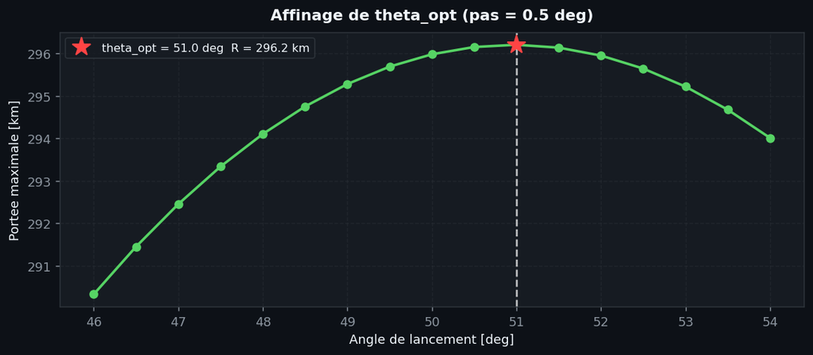

```
  Figure affinage sauvegardee.
  Recalcul pour theta_opt = 51.0 deg
  sweep_trajs recalcule pour 9 angles.
```

```python
# Affinage de theta_opt autour du resultat grossier (pas 0.5 deg)
angles_fine = np.arange(theta_opt - 4, theta_opt + 4.1, 0.5)
res_fine    = scan_angles(V0_R28, angles_fine, drag=True)

idx_fine      = np.argmax(res_fine[:, 3])
theta_refined = res_fine[idx_fine, 0]
range_refined = res_fine[idx_fine, 3]

print(f"  Grossier (3 deg) : theta_opt = {theta_opt}   -> R = {range_opt/1e3:.2f} km")
print(f"  Affine  (0.5 deg): theta_opt = {theta_refined} -> R = {range_refined/1e3:.2f} km")

fig_r, ax_r = plt.subplots(figsize=(9, 4))
fig_r.patch.set_facecolor(BG); ax_r.set_facecolor(PANEL)
for sp in ax_r.spines.values(): sp.set_edgecolor(BORDER)
ax_r.plot(res_fine[:, 0], res_fine[:, 3]/1e3, 'o-', color=C['ode45'], lw=2, ms=6)
ax_r.axvline(theta_refined, color='white', ls='--', lw=1.5, alpha=0.7)
ax_r.plot(theta_refined, range_refined/1e3, '*', color=C['exp'], ms=15, zorder=5,
          label='theta_opt = ' + str(theta_refined) + ' deg  R = ' + str(round(range_refined/1e3,2)) + ' km')
ax_r.set_xlabel('Angle de lancement [deg]', color=TEXT)
ax_r.set_ylabel('Portee maximale [km]', color=TEXT)
ax_r.set_title('Affinage de theta_opt (pas = 0.5 deg)', color=TEXT, fontweight='bold')
ax_r.tick_params(colors=MUTED); ax_r.grid(True, color=BORDER, alpha=0.4)
ax_r.legend(fontsize=9); plt.tight_layout()
plt.savefig(str(OUTPUT_DIR / 'harp_fig4_theta_opt_affine.png'), dpi=130,
            bbox_inches='tight', facecolor=BG)
plt.show()
print('  Figure affinage sauvegardee.')

# Mettre a jour theta_opt si l'affinage change le resultat
if theta_refined != theta_opt:
    theta_opt = theta_refined
    range_opt  = range_refined
    tE, sE = run_euler(theta_opt, V0_R28, dt=0.25)
    tR, sR = run_rk4(theta_opt,  V0_R28, dt=1.0)
    tO, sO = run_ode45(theta_opt, V0_R28)
    tA, sA = run_analytic(theta_opt, V0_R28)
    ta1, xa1, ya1, tl1, xr1 = get_key_points(tO, sO)
    gl_opt = compute_gload(tO, sO)
    vO     = np.hypot(sO[:, 2], sO[:, 3])
    MachO  = np.array([vO[i] / sound_speed(sO[i, 1]) for i in range(len(tO))])
    print(f'  Recalcul pour theta_opt = {theta_opt} deg')

# Reconstruire sweep_trajs avec le nouveau theta_opt
sweep_plot_angles = [10, 20, 30, theta_opt, 50, 60, 70, 80, 84.8]
# Deduplicate
seen = set()
sweep_plot_angles = [x for x in sweep_plot_angles if not (x in seen or seen.add(x))]
sweep_trajs = {}
for th in sweep_plot_angles:
    t_, s_ = run_ode45(th, V0_R28)
    sweep_trajs[th] = (t_, s_)
print(f"  sweep_trajs recalcule pour {len(sweep_trajs)} angles.")
```

## 2.6 Trajectoires, portée maximale et apogée

La figure suivante regroupe :

- la trajectoire $y(x)$ pour l’angle optimal ;
- un balayage des trajectoires pour plusieurs angles ;
- la portée maximale $x_{\max}(\theta_0)$ ;
- l’apogée $y_{\max}(\theta_0)$.

Cette figure montre deux choses :

1. la traînée atmosphérique réduit fortement la portée et l’apogée ;
2. l’angle optimal avec traînée est plus grand que $45^\circ$, parce qu’une trajectoire un peu plus verticale permet de quitter plus rapidement les basses couches denses de l’atmosphère.

```
  Création des figures…
  ✓  Figure 1 sauvegardée.
```

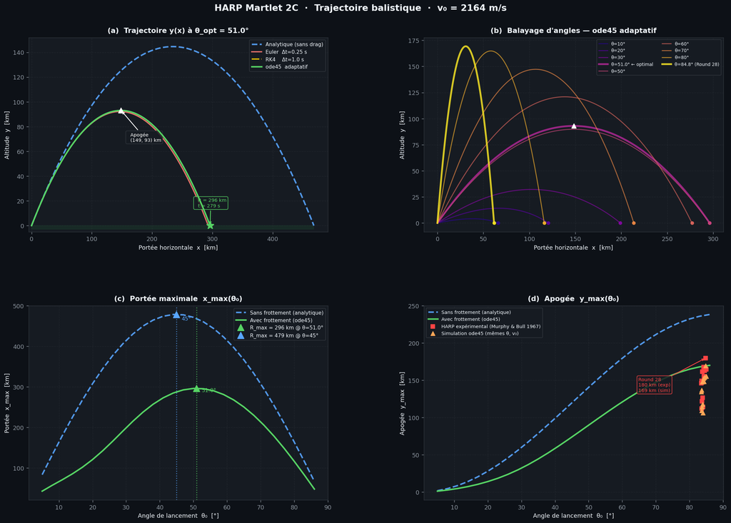

```python
# ══════════════════════════════════════════════════════════════════════
#  2.6  FIGURE 1 — Trajectoires et analyse des angles
# ══════════════════════════════════════════════════════════════════════
print("\n  Création des figures…")

fig1 = plt.figure(figsize=(18, 13))
fig1.patch.set_facecolor(BG)
gs1 = gridspec.GridSpec(2, 2, figure=fig1, hspace=0.38, wspace=0.32,
                         left=0.07, right=0.97, top=0.91, bottom=0.08)
fig1.suptitle(
    f"HARP Martlet 2C  ·  Trajectoire balistique  ·  v₀ = {V0_R28:.0f} m/s",
    fontsize=15, fontweight='bold', color=TEXT, y=0.97
)

# ── (a) Trajectoires y(x) à θ_opt — comparaison des méthodes ──────────
ax = fig1.add_subplot(gs1[0, 0])
ta1, xa1, ya1, tl1, xr1 = get_key_points(tO, sO)
ax.fill_between([0, max(sA[:, 0])/1e3], 0, -3, color='#1a3a2a', alpha=0.5)
ax.plot(sA[:, 0]/1e3, sA[:, 1]/1e3, color=C['nodrag'], lw=2.5, ls='--',
        label='Analytique (sans drag)', alpha=0.9, zorder=2)
ax.plot(sE[:, 0]/1e3, sE[:, 1]/1e3, color=C['euler'],  lw=2.0,
        label=f"Euler  Δt=0.25 s", alpha=0.9, zorder=3)
ax.plot(sR[:, 0]/1e3, sR[:, 1]/1e3, color=C['rk4'],   lw=2.0, ls='-.',
        label=f"RK4    Δt=1.0 s", alpha=0.9, zorder=4)
ax.plot(sO[:, 0]/1e3, sO[:, 1]/1e3, color=C['ode45'], lw=2.5,
        label="ode45  adaptatif", alpha=1.0, zorder=5)
# Apogée
ax.plot(xa1/1e3, ya1/1e3, '^', color='white', ms=9, zorder=6)
ax.annotate(f'  Apogée\n  ({xa1/1e3:.0f}, {ya1/1e3:.0f}) km',
            xy=(xa1/1e3, ya1/1e3), xytext=(xa1/1e3 + 10, ya1/1e3 - 25),
            fontsize=8, color='white',
            arrowprops=dict(arrowstyle='->', color='white', lw=1.3),
            bbox=dict(boxstyle='round,pad=0.3', fc=PANEL, ec=BORDER, alpha=0.85))
# Portée
ax.plot(xr1/1e3, 0, '*', color=C['ode45'], ms=13, zorder=6, mew=1.5)
ax.annotate(f'  R = {xr1/1e3:.0f} km\n  t = {tl1:.0f} s',
            xy=(xr1/1e3, 0), xytext=(xr1/1e3 - 25, 15),
            fontsize=8, color=C['ode45'],
            arrowprops=dict(arrowstyle='->', color=C['ode45'], lw=1.3),
            bbox=dict(boxstyle='round,pad=0.3', fc=PANEL, ec=C['ode45'], alpha=0.85))
style_ax(ax, title=f"(a)  Trajectoire y(x) à θ_opt = {theta_opt}°",
         xl='Portée horizontale  x  [km]', yl='Altitude  y  [km]')
ax.legend(fontsize=8.5, loc='upper right', framealpha=0.9)
ax.set_xlim(left=-5)
ax.set_ylim(bottom=-5)

# ── (b) Balayage d'angles (ode45) ──────────────────────────────────────
ax = fig1.add_subplot(gs1[0, 1])
cmap = plt.cm.plasma
n_sw = len(sweep_plot_angles)
cols_sw = cmap(np.linspace(0.05, 0.95, n_sw))
for i, th in enumerate(sweep_plot_angles):
    t_, s_ = sweep_trajs[th]
    is_opt = (th == theta_opt)
    is_r28 = (th == 84.8)
    lw  = 3.0 if (is_opt or is_r28) else 1.5
    lbl = (f'θ={th}° ← optimal' if is_opt else
           f'θ={th}° (Round 28)' if is_r28 else f'θ={th}°')
    ax.plot(s_[:, 0]/1e3, s_[:, 1]/1e3, color=cols_sw[i], lw=lw,
            label=lbl, alpha=0.85 if is_opt or is_r28 else 0.65)
    ax.plot(s_[-1, 0]/1e3, 0, 'o', color=cols_sw[i], ms=5, alpha=0.9)
# Marque l'apogée du cas optimal
t_sw, s_sw = sweep_trajs[theta_opt]
_, xs, ys, _, xrs = get_key_points(t_sw, s_sw)
ax.plot(xs/1e3, ys/1e3, '^', color='white', ms=8, zorder=5)
style_ax(ax, title='(b)  Balayage d\'angles — ode45 adaptatif',
         xl='Portée horizontale  x  [km]', yl='Altitude  y  [km]')
ax.legend(fontsize=7.5, loc='upper right', ncol=2, framealpha=0.9)

# ── (c) Portée x_max(θ) ────────────────────────────────────────────────
ax = fig1.add_subplot(gs1[1, 0])
ax.plot(res_nd[:, 0],   res_nd[:, 3]/1e3,   color=C['nodrag'], lw=2.5, ls='--',
        label='Sans frottement (analytique)', alpha=0.9)
ax.plot(res_drag[:, 0], res_drag[:, 3]/1e3, color=C['ode45'],  lw=2.5,
        label='Avec frottement (ode45)')
ax.axvline(theta_opt, color=C['ode45'], ls=':', lw=1.5, alpha=0.7)
ax.axvline(45,        color=C['nodrag'], ls=':', lw=1.5, alpha=0.7)
ax.plot(theta_opt, range_opt/1e3, '^', color=C['ode45'],  ms=11, zorder=5,
        label=f'R_max = {range_opt/1e3:.0f} km @ θ={theta_opt}°')
ax.plot(45,        range_nd/1e3,  '^', color=C['nodrag'], ms=11, zorder=5,
        label=f'R_max = {range_nd/1e3:.0f} km @ θ=45°')
ax.text(theta_opt+1.5, range_opt/1e3*0.97, f'{theta_opt}°', color=C['ode45'],  fontsize=9)
ax.text(46.5,          range_nd/1e3*0.97,  '45°',          color=C['nodrag'], fontsize=9)
style_ax(ax, title='(c)  Portée maximale  x_max(θ₀)',
         xl='Angle de lancement  θ₀  [°]', yl='Portée  x_max  [km]')
ax.legend(fontsize=8.5, framealpha=0.9)

# ── (d) Apogée y_max(θ) ────────────────────────────────────────────────
ax = fig1.add_subplot(gs1[1, 1])
ax.plot(res_nd[:, 0],   res_nd[:, 2]/1e3,   color=C['nodrag'], lw=2.5, ls='--',
        label='Sans frottement (analytique)', alpha=0.9)
ax.plot(res_drag[:, 0], res_drag[:, 2]/1e3, color=C['ode45'],  lw=2.5,
        label='Avec frottement (ode45)')
# Points expérimentaux
ax.scatter(EXP[:, 0], EXP[:, 2]/1e3, color=C['exp'], s=50, zorder=6,
           marker='s', label='HARP expérimental (Murphy & Bull 1967)')
ax.scatter(EXP[:, 0], sim_apos/1e3,   color=C['hi'],  s=50, zorder=6,
           marker='^', label='Simulation ode45 (mêmes θ, v₀)')
# Annotation Round 28
ax.annotate(f'Round 28\n{APO_R28/1e3:.0f} km (exp)\n{ya_V/1e3:.0f} km (sim)',
            xy=(TH_R28, APO_R28/1e3),
            xytext=(TH_R28 - 20, APO_R28/1e3*0.75),
            fontsize=8, color=C['exp'],
            arrowprops=dict(arrowstyle='->', color=C['exp'], lw=1.3),
            bbox=dict(boxstyle='round,pad=0.3', fc=PANEL, ec=C['exp'], alpha=0.85))
style_ax(ax, title='(d)  Apogée  y_max(θ₀)',
         xl='Angle de lancement  θ₀  [°]', yl='Apogée  y_max  [km]')
ax.legend(fontsize=8.0, framealpha=0.9)

plt.savefig(OUTPUT_DIR / 'harp_fig1_trajectoires.png',
            dpi=130, bbox_inches='tight', facecolor=BG)
print("  ✓  Figure 1 sauvegardée.")
plt.show()
```

## 2.7 Temps et position de l’apogée, puis temps et position au point d’impact

Pour l’angle optimal, les grandeurs suivantes sont extraites automatiquement des trajectoires simulées :

- angle optimal de portée
- portée maximale
- altitude maximale (apogée)
- position horizontale de l’apogée
- temps pour atteindre l’apogée
- temps de vol total (jusqu’à l’impact)

Les valeurs exactes sont imprimées à l’exécution dans les cellules de calcul principal (section 2.5) et dans le tableau récapitulatif (section 2.10).

Remarque méthodologique : de petites variations numériques peuvent apparaître (arrondis, pas angulaire, tolérances du solveur), mais l’interprétation physique reste inchangée.

## 2.8 Évolution temporelle

La figure suivante montre l’évolution temporelle des principales grandeurs :

- $x(t)$ : la position horizontale ;
- $y(t)$ : l’altitude ;
- $v_x(t)$ : la vitesse horizontale ;
- $v_y(t)$ : la vitesse verticale.

On observe que la vitesse horizontale diminue rapidement au début, car la traînée est très forte près du sol. La vitesse verticale décroît pendant la montée, s’annule à l’apogée, puis devient négative pendant la descente.

```
  ✓  Figure 2 sauvegardée.
```

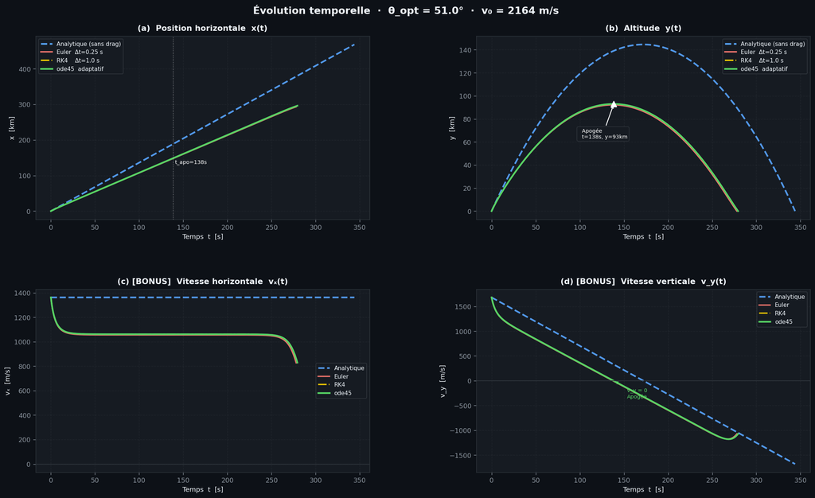

```python
# ══════════════════════════════════════════════════════════════════════
#  8.  FIGURE 2 — Évolution temporelle à θ_opt
# ══════════════════════════════════════════════════════════════════════
fig2 = plt.figure(figsize=(18, 11))
fig2.patch.set_facecolor(BG)
gs2 = gridspec.GridSpec(2, 2, figure=fig2, hspace=0.38, wspace=0.32,
                         left=0.07, right=0.97, top=0.91, bottom=0.08)
fig2.suptitle(
    f"Évolution temporelle  ·  θ_opt = {theta_opt}°  ·  v₀ = {V0_R28:.0f} m/s",
    fontsize=15, fontweight='bold', color=TEXT, y=0.97
)

legend_elements = [
    Line2D([0], [0], color=C['nodrag'], lw=2.5, ls='--', label='Analytique (sans drag)'),
    Line2D([0], [0], color=C['euler'],  lw=2.0,           label='Euler  Δt=0.25 s'),
    Line2D([0], [0], color=C['rk4'],   lw=2.0, ls='-.',  label='RK4    Δt=1.0 s'),
    Line2D([0], [0], color=C['ode45'], lw=2.5,            label='ode45  adaptatif'),
]

# ── (a) x(t) ──────────────────────────────────────────────────────────
ax = fig2.add_subplot(gs2[0, 0])
ax.plot(tA, sA[:, 0]/1e3, color=C['nodrag'], lw=2.5, ls='--', alpha=0.9)
ax.plot(tE, sE[:, 0]/1e3, color=C['euler'],  lw=2.0, alpha=0.9)
ax.plot(tR, sR[:, 0]/1e3, color=C['rk4'],   lw=2.0, ls='-.', alpha=0.9)
ax.plot(tO, sO[:, 0]/1e3, color=C['ode45'], lw=2.5)
# Annotation apogée
ax.axvline(ta1, color='white', ls=':', lw=1, alpha=0.5)
ax.text(ta1+2, sO[np.argmax(sO[:,1]),0]/1e3*0.97, f't_apo={ta1:.0f}s',
        color='white', fontsize=8, va='top')
style_ax(ax, title='(a)  Position horizontale  x(t)',
         xl='Temps  t  [s]', yl='x  [km]')
ax.legend(handles=legend_elements, fontsize=8.5, framealpha=0.9)

# ── (b) y(t) ──────────────────────────────────────────────────────────
ax = fig2.add_subplot(gs2[0, 1])
ax.plot(tA, sA[:, 1]/1e3, color=C['nodrag'], lw=2.5, ls='--', alpha=0.9)
ax.plot(tE, sE[:, 1]/1e3, color=C['euler'],  lw=2.0, alpha=0.9)
ax.plot(tR, sR[:, 1]/1e3, color=C['rk4'],   lw=2.0, ls='-.', alpha=0.9)
ax.plot(tO, sO[:, 1]/1e3, color=C['ode45'], lw=2.5)
# Annotations
ax.plot(ta1, ya1/1e3, '^', color='white', ms=9, zorder=5)
ax.annotate(f'  Apogée\n  t={ta1:.0f}s, y={ya1/1e3:.0f}km',
            xy=(ta1, ya1/1e3), xytext=(ta1-40, ya1/1e3-30),
            fontsize=8, color='white',
            arrowprops=dict(arrowstyle='->', color='white', lw=1.3),
            bbox=dict(boxstyle='round,pad=0.3', fc=PANEL, ec=BORDER, alpha=0.85))
style_ax(ax, title='(b)  Altitude  y(t)',
         xl='Temps  t  [s]', yl='y  [km]')
ax.legend(handles=legend_elements, fontsize=8.5, framealpha=0.9)

# ── (c) vx(t)  [BONUS] ─────────────────────────────────────────────────
ax = fig2.add_subplot(gs2[1, 0])
ax.plot(tA, sA[:, 2], color=C['nodrag'], lw=2.5, ls='--', alpha=0.9, label='Analytique')
ax.plot(tE, sE[:, 2], color=C['euler'],  lw=2.0, alpha=0.9, label='Euler')
ax.plot(tR, sR[:, 2], color=C['rk4'],   lw=2.0, ls='-.', alpha=0.9, label='RK4')
ax.plot(tO, sO[:, 2], color=C['ode45'], lw=2.5, label='ode45')
ax.axhline(0, color=BORDER, lw=1, ls='-')
style_ax(ax, title='(c) [BONUS]  Vitesse horizontale  vₓ(t)',
         xl='Temps  t  [s]', yl='vₓ  [m/s]')
ax.legend(fontsize=8.5, framealpha=0.9)

# ── (d) vy(t)  [BONUS] ─────────────────────────────────────────────────
ax = fig2.add_subplot(gs2[1, 1])
ax.plot(tA, sA[:, 3], color=C['nodrag'], lw=2.5, ls='--', alpha=0.9, label='Analytique')
ax.plot(tE, sE[:, 3], color=C['euler'],  lw=2.0, alpha=0.9, label='Euler')
ax.plot(tR, sR[:, 3], color=C['rk4'],   lw=2.0, ls='-.', alpha=0.9, label='RK4')
ax.plot(tO, sO[:, 3], color=C['ode45'], lw=2.5, label='ode45')
ax.axhline(0, color=BORDER, lw=1, ls='-')
ax.annotate(f'v_y = 0\nApogée',
            xy=(ta1, 0), xytext=(ta1+15, sO[:,3].min()*0.3),
            fontsize=8, color=C['ode45'],
            arrowprops=dict(arrowstyle='->', color=C['ode45'], lw=1.3))
style_ax(ax, title='(d) [BONUS]  Vitesse verticale  v_y(t)',
         xl='Temps  t  [s]', yl='v_y  [m/s]')
ax.legend(fontsize=8.5, framealpha=0.9)

plt.savefig(OUTPUT_DIR / 'harp_fig2_temporel.png',
            dpi=130, bbox_inches='tight', facecolor=BG)
print("  ✓  Figure 2 sauvegardée.")
plt.show()
```

### Comparaison de convergence des méthodes numériques

La comparaison des solveurs montre le comportement attendu en analyse numérique :

- **Euler** (ordre 1) est le moins précis et accumule davantage l’erreur globale.
- **RK4** (ordre 4) améliore nettement la précision à pas de temps modéré.
- **RK45/ode45** (ordre 4–5 adaptatif) sert de référence numérique grâce au contrôle d’erreur local.
- La **solution analytique sans traînée** reste un cas limite utile pour illustrer l’effet physique majeur de la traînée atmosphérique.

Dans les sorties du notebook, on observe que RK4 et RK45 donnent des résultats très proches pour les grandeurs globales (portée, apogée, temps de vol), ce qui renforce la confiance dans la stabilité et la cohérence du modèle implémenté.

## 2.9 BONUS — Courbe, charge et coefficient de traînée

Dans la partie bonus, on a inclus :

- une représentation de l’altitude en fonction de la vitesse totale $y(v)$ ;
- l’évolution de la charge structurale en $g$ ;
- un graphique du coefficient de traînée $C_D$ en fonction du Mach.

La charge structurale utilisée dans le code est : $$ n_g = \frac{|a_{\mathrm{drag}}|}{g_0} = \frac{\rho(y) C_D A v^2}{2mg_0}. $$

Le résultat principal est que la charge maximale est d’environ : $$ n_{g,\max} \approx 10.7\,g, $$ et qu’elle se produit au lancement, lorsque la vitesse et la densité atmosphérique sont toutes deux maximales.

```
  ✓  Figure 3 sauvegardée.
```

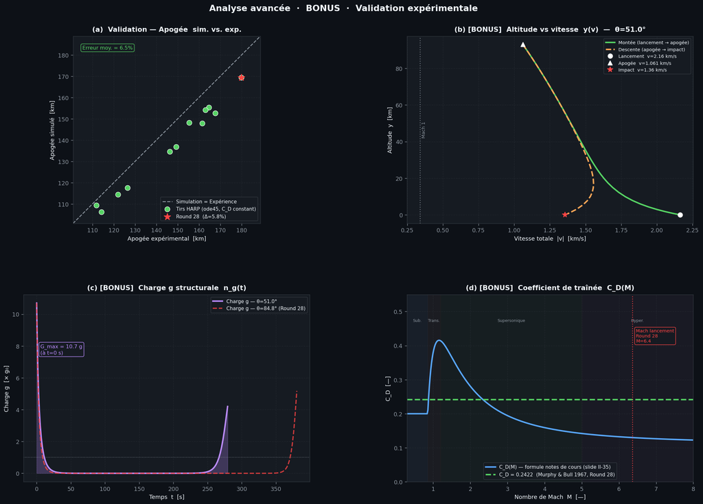

```python
# ══════════════════════════════════════════════════════════════════════
#  9.  FIGURE 3 — BONUS + Validation complète
# ══════════════════════════════════════════════════════════════════════
fig3 = plt.figure(figsize=(18, 13))
fig3.patch.set_facecolor(BG)
gs3 = gridspec.GridSpec(2, 2, figure=fig3, hspace=0.38, wspace=0.34,
                         left=0.07, right=0.97, top=0.91, bottom=0.08)
fig3.suptitle(
    "Analyse avancée  ·  BONUS  ·  Validation expérimentale",
    fontsize=15, fontweight='bold', color=TEXT, y=0.97
)

# ── (a) Validation apogée sim vs exp ──────────────────────────────────
ax = fig3.add_subplot(gs3[0, 0])
lims = [min(EXP[:,2].min(), sim_apos.min())/1e3 * 0.95,
        max(EXP[:,2].max(), sim_apos.max())/1e3 * 1.05]
ax.plot(lims, lims, color=MUTED, lw=1.5, ls='--', label='Simulation = Expérience')
ax.scatter(EXP[:, 2]/1e3, sim_apos/1e3, color=C['ode45'], s=80, zorder=5,
           label='Tirs HARP (ode45, C_D constant)', edgecolors='white', lw=0.7)
# Round 28 en surbrillance
ax.scatter([APO_R28/1e3], [ya_V/1e3], color=C['exp'], s=150, zorder=6,
           marker='*', label=f'Round 28  (Δ={abs(ya_V-APO_R28)/APO_R28*100:.1f}%)')
ax.set_xlim(lims); ax.set_ylim(lims)
ax.set_aspect('equal')
style_ax(ax, title='(a)  Validation — Apogée  sim. vs. exp.',
         xl='Apogée expérimental  [km]', yl='Apogée simulé  [km]')
ax.legend(fontsize=8.5, framealpha=0.9)
# Erreur moyenne
ax.text(0.05, 0.95, f'Erreur moy. = {np.mean(np.abs(errs_apo)):.1f}%',
        transform=ax.transAxes, fontsize=9, color=C['ode45'], va='top',
        bbox=dict(boxstyle='round', fc=PANEL, ec=C['ode45'], alpha=0.8))

# ── (b) Altitude vs vitesse totale — y(v)  [BONUS] ─────────────────────
ax = fig3.add_subplot(gs3[0, 1])
# Monter = aller, descendre = retour  (couleur différente)
i_apo = np.argmax(sO[:, 1])
ax.plot(vO[:i_apo]/1e3, sO[:i_apo, 1]/1e3, color=C['ode45'], lw=2.5,
        label='Montée (lancement → apogée)')
ax.plot(vO[i_apo:]/1e3, sO[i_apo:, 1]/1e3, color=C['hi'], lw=2.5, ls='--',
        label='Descente (apogée → impact)')
# Marqueurs clés
ax.plot(vO[0]/1e3,    sO[0, 1]/1e3,    'o', color='white', ms=8, zorder=5,
        label=f'Lancement  v={vO[0]/1e3:.2f} km/s')
ax.plot(vO[i_apo]/1e3, sO[i_apo, 1]/1e3, '^', color='white', ms=8, zorder=5,
        label=f'Apogée  v={vO[i_apo]/1e3:.3f} km/s')
ax.plot(vO[-1]/1e3,   sO[-1, 1]/1e3,   '*', color=C['exp'], ms=10, zorder=5,
        label=f'Impact  v={vO[-1]/1e3:.2f} km/s')
# Vitesse du son (Mach 1 ≈ 340 m/s)
ax.axvline(sound_speed(0)/1e3, color=MUTED, ls=':', lw=1.5, alpha=0.7)
ax.text(sound_speed(0)/1e3 + 0.01, sO[:, 1].max()*0.5/1e3, 'Mach 1',
        color=MUTED, fontsize=8, rotation=90, va='center')
style_ax(ax, title=f'(b) [BONUS]  Altitude vs vitesse  y(v)  —  θ={theta_opt}°',
         xl='Vitesse totale  |v|  [km/s]', yl='Altitude  y  [km]')
ax.legend(fontsize=8, framealpha=0.9)

# ── (c) Charge g  [BONUS] ──────────────────────────────────────────────
ax = fig3.add_subplot(gs3[1, 0])
ax.fill_between(tO, gl_opt, color=C['gload'], alpha=0.25)
ax.plot(tO, gl_opt, color=C['gload'], lw=2.5, label=f'Charge g — θ={theta_opt}°')

# Valider aussi pour Round 28 (quasi-vertical)
gl_r28 = compute_gload(tV, sV)
ax.plot(tV, gl_r28, color=C['exp'], lw=2.0, ls='--', alpha=0.8,
        label=f'Charge g — θ={TH_R28}° (Round 28)')

ax.axhline(1, color=MUTED, ls=':', lw=1, alpha=0.7)
ax.text(tO[-1]*0.02, gl_opt.max()*0.7,
        f'G_max = {gl_opt.max():.1f} g\n(à t={tO[np.argmax(gl_opt)]:.0f} s)',
        fontsize=9, color=C['gload'],
        bbox=dict(boxstyle='round', fc=PANEL, ec=C['gload'], alpha=0.85))
style_ax(ax, title='(c) [BONUS]  Charge g structurale  n_g(t)',
         xl='Temps  t  [s]', yl='Charge g  [× g₀]')
ax.legend(fontsize=8.5, framealpha=0.9)

# ── (d) CD(Mach) vs formule  [BONUS] ───────────────────────────────────
ax = fig3.add_subplot(gs3[1, 1])
M_range = np.linspace(0.3, 8, 400)
cd_formula = np.array([cd_mach(m * 340, 0) for m in M_range])
ax.plot(M_range, cd_formula, color=C['nodrag'], lw=2.5,
        label='C_D(M) — formule notes de cours (slide II-35)')
ax.axhline(CD_CONST, color=C['ode45'], lw=2.5, ls='--',
           label=f'C_D = {CD_CONST:.4f}  (Murphy & Bull 1967, Round 28)')
# Mach au lancement de Round 28
M_launch = V0_R28 / sound_speed(0)
ax.axvline(M_launch, color=C['exp'], ls=':', lw=1.5, alpha=0.8)
ax.text(M_launch + 0.1, 0.45, f'Mach lancement\nRound 28\nM={M_launch:.1f}',
        fontsize=8, color=C['exp'], va='top',
        bbox=dict(boxstyle='round', fc=PANEL, ec=C['exp'], alpha=0.8))
# Régimes
for x_lo, x_hi, label, col in [
    (0.3, 0.85, 'Sub.', '#2a4a6a'),
    (0.85, 1.2, 'Trans.', '#4a2a2a'),
    (1.2, 5.0, 'Supersonique', '#1a3a1a'),
    (5.0, 8.0, 'Hyper.', '#3a1a3a'),
]:
    ax.axvspan(x_lo, x_hi, alpha=0.10, color=col)
    ax.text((x_lo+x_hi)/2, 0.47, label, ha='center', fontsize=7, color=MUTED)
style_ax(ax, title='(d) [BONUS]  Coefficient de traînée  C_D(M)',
         xl='Nombre de Mach  M  [—]', yl='C_D  [—]')
ax.legend(fontsize=8.5, framealpha=0.9)
ax.set_ylim(0, 0.55)
ax.set_xlim(0.3, 8)

plt.savefig(OUTPUT_DIR / 'harp_fig3_bonus_validation.png',
            dpi=130, bbox_inches='tight', facecolor=BG)
print("  ✓  Figure 3 sauvegardée.")
plt.show()
```

## 2.10 Tableau récapitulatif des résultats numériques

La cellule suivante imprime un résumé final de toutes les grandeurs importantes obtenues dans la simulation :

- angle optimal
- portée
- apogée
- temps d’apogée
- temps de vol
- validation Round 28
- résultats bonus

```python
# ══════════════════════════════════════════════════════════════════════
#  10.  TABLEAU RÉCAPITULATIF
# ══════════════════════════════════════════════════════════════════════
print("\n" + "═" * 64)
print("  TABLEAU DE RÉSULTATS — DEVOIR #3")
print("═" * 64)
print(f"\n  Projectile   : HARP Martlet 2C")
print(f"  Masse        : {M_PROJ} kg            Diamètre : {D_PROJ*100:.1f} cm")
print(f"  C_D          : {CD_CONST:.4f} (const)  A = {A_PROJ*1e4:.2f} cm²")
print(f"  v₀ (Round 28): {V0_R28:.0f} m/s  (Mach {V0_R28/sound_speed(0):.1f})")
print(f"\n  Angle optimal (portée max, ode45) :  θ_opt = {theta_opt}°")
print(f"  Sans frottement (analytique)      :  balayage discret = {theta_nd:.0f}°  |  optimum analytique exact = 45°")
print(f"\n  À θ_opt = {theta_opt}°  (ode45, v₀={V0_R28:.0f} m/s) :")
print(f"    Portée max         : {range_opt/1e3:.1f} km")
print(f"    Apogée             : {apo_opt/1e3:.1f} km")
_, xa_o, ya_o, tl_o, xr_o = get_key_points(tO, sO)
print(f"    Pos. apogée        : ({xa_o/1e3:.1f}, {ya_o/1e3:.1f}) km")
print(f"    Temps d'apogée     : {ta1:.0f} s")
print(f"    Temps de vol total : {tl_o:.0f} s")
print(f"\n  Validation Round 28 (θ={TH_R28}°, v₀={V0_R28:.0f} m/s) :")
print(f"    Apogée sim.  : {ya_V/1e3:.1f} km  |  exp.  : {APO_R28/1e3:.1f} km  |  Δ = {abs(ya_V-APO_R28)/APO_R28*100:.1f}%")
print(f"    Portée sim.  : {xr_V/1e3:.1f} km  |  exp.  : {RNG_R28/1e3:.1f} km  |  Δ = {abs(xr_V-RNG_R28)/RNG_R28*100:.1f}%")
print(f"\n  BONUS :")
print(f"    G-load max en vol  : {gl_opt.max():.1f} g  (à t={tO[np.argmax(gl_opt)]:.0f} s)")
print(f"    Mach au lancement  : {MachO[0]:.2f}")
print(f"    Vitesse d'impact   : {vO[-1]:.0f} m/s  (Mach {MachO[-1]:.2f})")
print("═" * 64)
```

[output not shown]

## 3. Validation expérimentale

La validation compare la simulation aux données expérimentales HARP, principalement pour le Round 28 :

$$ \theta = 84.8^\circ,\qquad v_0 \approx 2163\text{ à }2164\,\mathrm{m/s}. $$

Les valeurs simulées et expérimentales (apogée, portée) ainsi que les erreurs relatives sont calculées automatiquement dans la cellule de calcul principal. Une validation sur l’ensemble des tirs disponibles est aussi effectuée pour estimer l’erreur moyenne et l’erreur maximale.

Cette comparaison montre que le modèle reproduit correctement les tendances globales, avec des écarts compatibles avec les hypothèses simplificatrices (2D, $C_D$ constant dans le cas principal, vent négligé, atmosphère simplifiée).

## 4. Analyse et discussion des résultats

Les résultats montrent d’abord que la traînée atmosphérique joue un rôle majeur dans la trajectoire. Le modèle sans frottement surestime fortement la portée et l’apogée, ce qui confirme qu’un traitement purement parabolique est inadéquat à plus de $2\,\mathrm{km/s}$.

Ensuite, l’angle optimal de lancement se situe autour de $50$–$51^\circ$. Ce décalage est physiquement cohérent : une trajectoire légèrement plus verticale permet de quitter plus rapidement les couches basses denses de l’atmosphère, où les pertes aérodynamiques sont les plus fortes.

La comparaison Euler, RK4 et RK45 montre que les méthodes d’ordre élevé convergent vers des résultats très proches. Euler reste utile comme référence pédagogique, mais avec une précision plus faible.

Enfin, la validation expérimentale est satisfaisante : les écarts observés demeurent plausibles compte tenu des simplifications du modèle :

- mouvement strictement 2D ;
- coefficient de traînée constant dans le cas principal ;
- absence de vent latéral et d’effets météorologiques détaillés ;
- absence de portance ;
- atmosphère exponentielle simplifiée.

## 5. Conclusion

Dans ce travail, on a étudié la trajectoire balistique du projectile HARP Martlet 2C avec un modèle numérique incluant :

- une gravité variable avec l’altitude ;
- une atmosphère exponentielle ;
- une traînée quadratique de Newton.

Le résultat principal est que l’angle de lancement optimal pour la portée maximale se situe autour de $50$–$51^\circ$, soit au-dessus de la valeur idéale $45^\circ$ sans traînée.

Les sorties numériques (portée, apogée, temps caractéristiques, validation Round 28, bonus) sont calculées automatiquement et résumées dans la section 2.10. Elles confirment l’impact dominant de la traînée et la cohérence globale du modèle avec les données expérimentales HARP.

Ce travail met en évidence l’importance des effets atmosphériques dans l’analyse balistique d’un projectile réel lancé à très haute vitesse, et illustre l’intérêt des solveurs d’ordre élevé pour obtenir des résultats robustes.

## 6. Sources

Les principales sources utilisées dans ce travail sont :

1. Énoncé du devoir 3 du cours PHY-2100 — Sciences de l’espace.
2. Notes de cours TIRS et code de base mentionné dans l’énoncé.
3. Murphy, C. H., & Bull, G. V. (1967). *HARP 5-Inch and 16-Inch Guns at Yuma Proving Ground, Arizona* (BRL Memorandum Report No. 1825). U.S. Army Ballistic Research Laboratories.
4. Documentation SciPy — `scipy.integrate.solve_ivp` (méthode RK45).
5. Documentation Matplotlib — génération de figures scientifiques et styles de tracé.

Remarque : toutes les hypothèses de modélisation (atmosphère exponentielle, gravité variable, traînée quadratique, coefficient de traînée constant ou dépendant du Mach) suivent l’énoncé et les notes du cours.